# Зах зээлийн эрсдэлийг хэмжих ARMA-GARCH хязгаарлалт

Lkhagvasuren

3/20/2020

*Код* : [github repo](https://github.com/lhagwasuren/Youtube-channel/blob/master/UFE/GARCH_VaR/GARCH_VaR.R)

*Бичлэг*: [Youtube](https://youtu.be/UiqQR4n1U5o?list=PLVebDyRdbYjBAlAYD8biJSpXTnCoAY7NZ)

Энэхүү илтгэлээр зах зээлийн эрсдэлийн хэмжих VaR аргачлалын төрлүүдийг харьцуулан харна. Үүнд энгийн VaR, EWMA VaR болон ARMA-GARCH VaR хязгаарлалтууд хамаарна. Онолын агуулгыг бус зөвхөн практик хэрэглээг харуулахыг зорьсон тул бусад сонсогчид маань *wikipedia* аас дэлгэрүүлж унших боломжтой.

## Data and packages

[Quantmod](https://cran.r-project.org/web/packages/quantmod/quantmod.pdf) багцын тусламжтай yahoo-finance - аас DELL компанийн хувьцааны хаалтын ханшийн мэдээллийг импортолж, [Rugarch](https://cran.r-project.org/web/packages/rugarch/rugarch.pdf) багцын тусламжтай VaR хязгаарлалтуудыг үнэлсэн болно.

```r
library(quantmod)  # import data from API
library(dygraphs)  # time series plotting
library(tseries)   # time series analysis
library(tidyverse) # data wrangling
library(forecast)  # best package of forecasting
library(rugarch)   # ARMA-GARCH modelling

# import DELL data from yahoo-finance
getSymbols(Symbols = "DELL",from='2016-08-17',to='2020-03-19',auto.assign = T)
```

```
## [1] "DELL"
```

```r
# some graphs
graph<-dygraph(OHLC(DELL))
dyCandlestick(graph)
```

[interactive chart not shown]

## Return

Арифметик өгөөжийг тооцож `auto.arima()` функцээр эрэмбийг тодорхойлов. Энэхүү функц нь AIC,SIC мэдээллийн шинжүүрийн тусламжтай оновчтой загварын сонгодог. `?auto.arima()` гэж тайлбарын авах боломжтой.

```r
r = log(DELL$DELL.Close)

r = diff(DELL$DELL.Close)/lag(DELL$DELL.Close)
r = na.omit(r)

names(r)="Return"  # change column name

head(r)  # show first 6 values
```

```
##                  Return
## 2016-08-18 -0.005813976
## 2016-08-19  0.017543800
## 2016-08-22  0.003448339
## 2016-08-23  0.030927780
## 2016-08-24  0.013333377
## 2016-08-25 -0.004166672
```

```r
Box.test(r,type = 'Box-Pierce') # Box-Pierce test to show stationary or non stationary
```

```
##
##  Box-Pierce test
##
## data:  r
## X-squared = 1.2316, df = 1, p-value = 0.2671
```

```r
model_arima = auto.arima(r)
summary(model_arima)
```

```
## Series: r
## ARIMA(1,1,0)
##
## Coefficients:
##           ar1
##       -0.5041
## s.e.   0.0288
##
## sigma^2 estimated as 0.0006509:  log likelihood=2025.03
## AIC=-4046.05   AICc=-4046.04   BIC=-4036.45
##
## Training set error measures:
##                         ME       RMSE        MAE MPE MAPE      MASE       ACF1
## Training set -9.611467e-05 0.02548447 0.01607176 NaN  Inf 0.8613313 -0.1751226
```

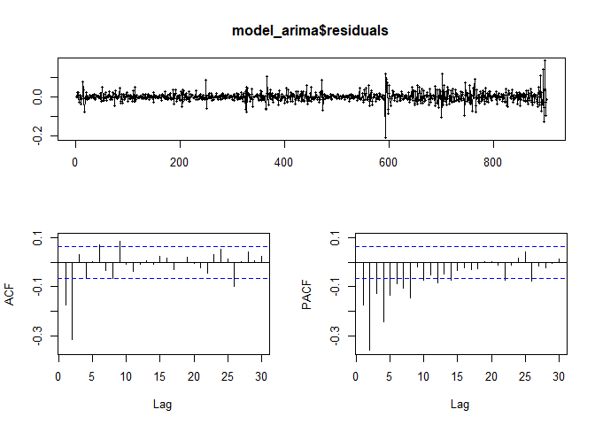

```r
tsdisplay(model_arima$residuals) # plot residuals
```

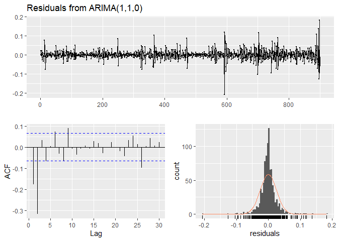

```
##
##  Ljung-Box test
##
## data:  Residuals from ARIMA(1,1,0)
## Q* = 140.87, df = 9, p-value < 2.2e-16
##
## Model df: 1.   Total lags used: 10
```

```r
checkresiduals(model_arima) # forecast package's nice function
```

## ARMA-GARCH VaR

rugarch багцын ugarchspec болон ugarchfit функцүүдийн тусламжтай ARMA-GARCH загвар үнэлэв. Энэ багцтай холбоотой мэдээллийг [CRAN](https://cran.r-project.org/web/packages/rugarch/rugarch.pdf) аас авна уу.

```r
# define spec
spec = ugarchspec(variance.model = list(model = 'sGARCH',
                                         garchOrder = c(1,1)),
                    mean.model = list(armaOrder=c(1,0),arfima=T,
                    include.mean = F),
                    distribution="norm")
# Estimate model
fit = ugarchfit(spec = spec, data = r)

mu = fitted(fit)
sigma = sigma(fit)

GARCH_VaR = mu + qnorm(.05)*sigma # VaR garch

#plot(fit) # 12 plots. 1-12 change plots and 0-exit

test = VaRTest(.05,r,GARCH_VaR) # backward testing
names(test)
```

```
##  [1] "expected.exceed" "actual.exceed"   "uc.H0"           "uc.LRstat"
##  [5] "uc.critical"     "uc.LRp"          "uc.Decision"     "cc.H0"
##  [9] "cc.LRstat"       "cc.critical"     "cc.LRp"          "cc.Decision"
```

```r
test$actual.exceed/length(r)
```

```
## [1] 0.03107658
```

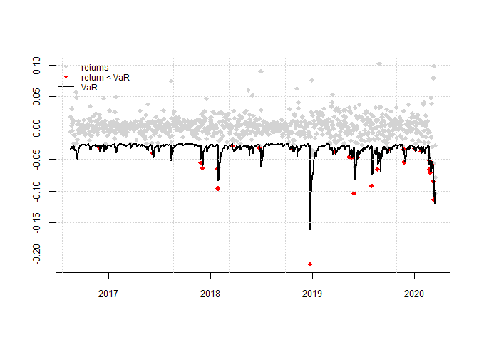

```r
VaRplot(.05,r,GARCH_VaR)  # return and Var
```

## Simple and EWMA VaR

EWMA VaR хязгаарлалт нь ARMA-GARCH VaR загварын тухайн тохиолдол билээ. Тухайлбал EWMA загварын дундажын үнэлгээ нь $\phi_0 = 0,\phi_1=\lambda,p=1,\theta_1=(1-\lambda), q=1$ байх $ARMA(1,1)$ процесс бол, вариацын үнэлгээ нь $\omega=0,\beta_1=\lambda,k=1,\alpha_1=(1-\lambda),l=1$ байх $GARCH(1,1)$ процесс байна.

```r
VaRStatic <- sd(r) * qnorm(0.05)

spec2 = ugarchspec(variance.model=list(model="iGARCH",
                                       garchOrder=c(1,1)),
                   mean.model=list(armaOrder=c(1,0),
                                   include.mean=F),
                   distribution.model="norm",
                   fixed.pars=list(omega=0))

ewma_fit = ugarchfit(spec = spec2, data = r)

coef(ewma_fit)
```

```
##         ar1       omega      alpha1       beta1
## 0.065597767 0.000000000 0.009062311 0.990937689
```

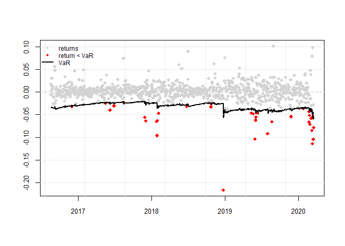

```r
EWMA_VaR = fitted(ewma_fit) + qnorm(.05)*sigma(ewma_fit)

VaRplot(.05,r,EWMA_VaR)
```

## Putting it all together

DELL компанийн хувьцааны ханшийн өгөөж болон бусад VaR хязгаарлалтыг нэг хавтгайд дүрслэв.

```r
VaRs = cbind(r, VaRStatic, GARCH_VaR, EWMA_VaR)

head(VaRs)
```

```
##                  Return   VaRStatic   GARCH_VaR    EWMA_VaR
## 2016-08-18 -0.005813976 -0.03511932 -0.03501781 -0.03509563
## 2016-08-19  0.017543800 -0.03511932 -0.03271075 -0.03532949
## 2016-08-22  0.003448339 -0.03511932 -0.03149029 -0.03375160
## 2016-08-23  0.030927780 -0.03511932 -0.02963434 -0.03451958
## 2016-08-24  0.013333377 -0.03511932 -0.03265176 -0.03289168
## 2016-08-25 -0.004166672 -0.03511932 -0.03065667 -0.03393229
```

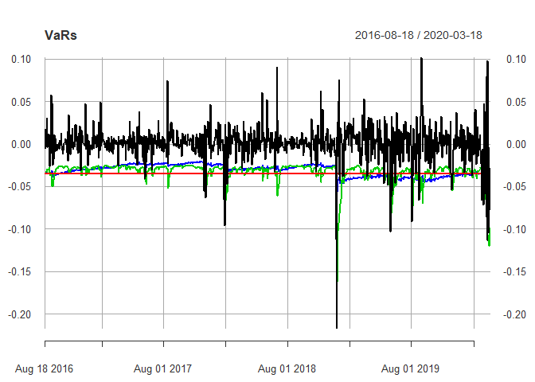

```r
# plot with rugarch
plot(VaRs)
```

```r
# dygraph plot
dygraph(VaRs,main = 'Dell return and VaRs',
        xlab ='Date',ylab = "Rate" )
```

[interactive chart not shown]

# Source

- Ц.Батсүх багшийн лекцийн материал [Ц.Батсүх](https://www.mongolbank.mn/news.aspx?tid=1&id=1932)
- [Fitting and Predicting VaR based on an ARMA-GARCH Process](https://cran.r-project.org/web/packages/qrmtools/vignettes/ARMA_GARCH_VaR.html)
- [VaR with GARCH(1,1)](https://rpubs.com/DejanPrv/VarGarch)
- [Can we forecast gold prices using classical time series models?](https://www.rpubs.com/ddbs/gldforecasting)
- [Rugarch](https://cran.r-project.org/web/packages/rugarch/rugarch.pdf)